# STA426 Exercise 8: loess/lowess, adjusting for a batch effect, differential exon usage

## Question 1.

Simulate data from the sine curve (from `0` to `2*pi`) with Gaussian noise added (as shown in the lecture). Try and “normalize” the sine curve data. That is, **subtract** the trend of the data, such that if the normalization succeeds, you are left with normally distributed data centred around zero. After this: i) make a plot of the normalized data; ii) make a plot of the difference between the truth (sine curve) and the loess/lowess estimate; iii) create a quantile-quantile (against Gaussian) plot of the normalized data. Comment on the results. Did your normalization work? Does it look (sufficiently) Gaussian? You may need to play with parameters to get a “good” lowess/loess estimate in the first place.

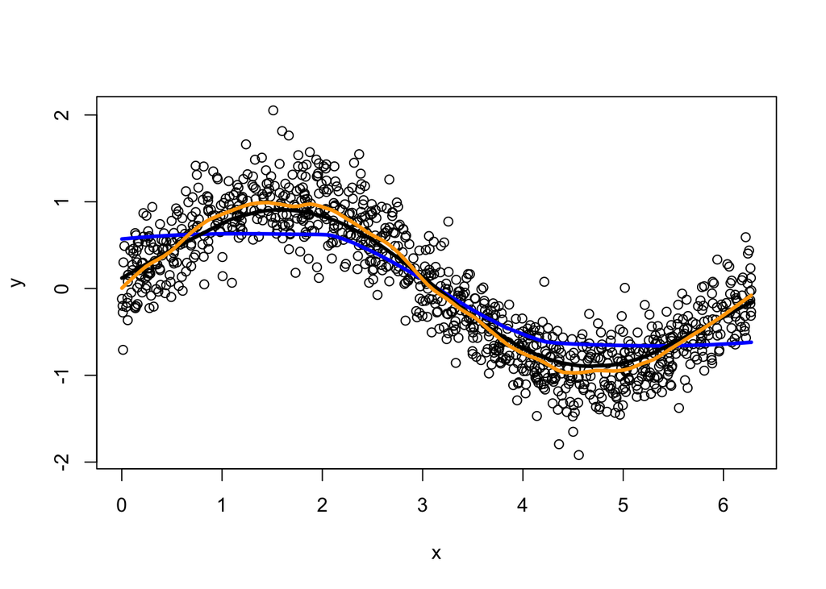

```r
x <- runif(1000, 0, 2*pi)
y <- sin(x) + rnorm(1000, sd = .3)

plot(x,y)
lines(lowess(y~x, f=2/3), col="blue", lwd=3)
lines(lowess(y~x, f=1/3), col="black", lwd=3)
lines(lowess(y~x, f=1/10), col="orange", lwd=3)
```

## Question 2.

Next, we will revisit the analysis from Exercise 7 (pasilla dataset), to account for a covariate. In the second part, we will use (preprocessed) exon-level counts to look for changes in splicing.

```r
(samples <- read.table("samples.txt", header=TRUE,
                      row.names=5, stringsAsFactors=FALSE))
```

```
                  rep condition libtype shortname           countfile
CG8144_RNAi-1.bam  T1         T      SE     T1.SE CG8144_RNAi-1.count
CG8144_RNAi-3.bam  T3         T      PE     T3.PE CG8144_RNAi-3.count
CG8144_RNAi-4.bam  T4         T      PE     T4.PE CG8144_RNAi-4.count
Untreated-1.bam    C1         C      SE     C1.SE   Untreated-1.count
Untreated-6.bam    C6         C      SE     C6.SE   Untreated-6.count
Untreated-3.bam    C3         C      PE     C3.PE   Untreated-3.count
Untreated-4.bam    C4         C      PE     C4.PE   Untreated-4.count
```

Take the data from Exercise 7 and produce an MDS plot again, but this time colour the points according to the `libtype` covariate in the samples table: SE = single end, PE = paired end (i.e., a technical detail of the library construction); perhaps also label the points on the MDS plot using the `shortname` column to make them easy to distinguish. Comment on the relative positions of the samples.

## Question 3.

Put a factor variable for the `libtype` covariate in the design matrix and redo the edgeR or limma differential expression analysis from Exercise 7 (i.e., include also the biological factor of interest, knockout state, in the design matrix). This now represents modeling where we are still interested in the knockout state, but the model now *adjusts* for the effects of `libtype` (with some assumptions). Compare the set of genes called DE from Exercise 7 (i.e., without accounting for the covariate) to this new analysis. Identify and plot (normalized) expression levels of a gene that is affected solely by library type (i.e., and not by knockout state).

## Question 4.

Next, we will explore “differential splicing”, using the same pasilla dataset, but here we will instead use exon-level summaries of the data (as mentioned in lectures). Some extra background on getting this data can be found in the [`DEXSeq` documentation](https://bioconductor.org/packages/release/bioc/vignettes/DEXSeq/inst/doc/DEXSeq.html).

```r
library(pasilla)
(sdir <- file.path(system.file(package="pasilla"), "extdata"))
```

```
[1] "/Users/mark/Library/R/arm64/4.5/library/pasilla/extdata"
```

```r
dir(sdir)
```

```
 [1] "Dmel.BDGP5.25.62.DEXSeq.chr.gff" "geneIDsinsubset.txt"
 [3] "pasilla_gene_counts.tsv"         "pasilla_sample_annotation.csv"
 [5] "treated1fb.txt"                  "treated2fb.txt"
 [7] "treated3fb.txt"                  "untreated1fb.txt"
 [9] "untreated2fb.txt"                "untreated3fb.txt"
[11] "untreated4fb.txt"
```

```r
anno <- file.path(sdir, "Dmel.BDGP5.25.62.DEXSeq.chr.gff")

samplesX = data.frame(cond = rep( c("trt","untrt"), c(3,4) ),
                      type = c("SE","PE","PE","SE","SE","PE","PE"),
                      countfile = dir(sdir,pattern="fb.txt"),
                      stringsAsFactors = TRUE)
samplesX
```

```
   cond type        countfile
1   trt   SE   treated1fb.txt
2   trt   PE   treated2fb.txt
3   trt   PE   treated3fb.txt
4 untrt   SE untreated1fb.txt
5 untrt   SE untreated2fb.txt
6 untrt   PE untreated3fb.txt
7 untrt   PE untreated4fb.txt
```

Below is some unevaluated code that represents a standard `DEXSeq` pipeline (the code will not run as is; you will need to make some modifications):

```r
library(DEXSeq)
dxd <- DEXSeqDataSetFromHTSeq(
           countfiles=file.path( sdir, filename ),
           sampleData = samples,
           design = ~ sample + exon + type:exon + condition:exon)
dxd <- estimateSizeFactors( dxd )
dxd <- estimateDispersions( dxd )
dxd <- testForDEU( dxd )
dxr <- DEXSeqResults( dxd )
```

Refer to the [`DEXSeq` vignette](https://bioconductor.org/packages/release/bioc/vignettes/DEXSeq/inst/doc/DEXSeq.html) or the documentation for further details.

Fix the above code to run a standard `DEXSeq` analysis and plot one of the top differentially spliced genes – for example, see the `plotDEXSeq()` function. As discussed in the lecture, the model should find genes that show a *departure from parallelism* in terms of their exon-level counts.